# SAoTD Vignette

Evan Munson

2018-02-14

# Sentiment Analysis of Twitter Data (SAoTD)

## Twitter Introduction

Recent years have witnessed the rapid growth of social media platforms in which users can publish their individual thoughts and opinions (e.g., Facebook, Twitter, Google+ and several blogs). The rise in popularity of social media has changed the world wide web from a static repository to a dynamic forum for anyone to voice their opinion across the globe. This new dimension of *User Generated Content* opens up a new and dynamic source of insight to individuals, organizations and governments.

Social network sites or platforms, are defined as web-based services that allow individuals to:

- Construct a public or semi-public profile within a bounded system.
- Articulate a list of other users with whom they share a connection.
- View and traverse their list of connections and those made by others within the system.

The nature and nomenclature of these connections may vary from site to site.

This package, `SAoTD` is focused on utilizing Twitter data due to its widespread global acceptance. Harvested data, analyzed for sentiment can provide powerful insight into a population. This insight can assist organizations, by letting them better understand their target population. This package will allow a useer to acquire data using the Public Twitter Application Programming Interface (API), to obtain tweets.

The `SAoTD` package is broken down into five different phases:

- Acquire
- Explore
- Topic Analysis
- Sentiment Calculation
- Visualization

## Packages

```r
library(SAoTD)
library(tidyverse)
library(tidytext)
library(kableExtra)
library(utils)
```

## Acquire

To explore the data manipulation functions of `SAoTD` we will use the built in dataset `SAoTD::raw_tweets`.

However is you want to acquire your own tweets, you will first have to:

1. Create a [twitter](https://twitter.com/) account or sign into existing account.
2. Use your twitter login, to sign into [Twitter Developers](https://dev.twitter.com/apps/)
3. Navigate to My Applications.
4. Fill out the new application form.
   - You will be asked to provide a website.
   - You can input your twitter account website.
   - For example: https://twitter.com/yourusername
5. Create access token.
   - Record twitter access keys and tokens

With these steps complete you now have access to the twitter API.

To acquire your own dataset of tweets you can use the `SAoTD::Acquire` function and insert your consumer key, consumer secret key, access token and access secret key gained from the [Twitter Developers](https://dev.twitter.com/apps/) page.

```r
consumer_key <- "XXXXXXXXXXXXXXXXXXXXXXXXX"
consumer_secret <- "XXXXXXXXXXXXXXXXXXXXXXXXXXXXXXXXXXXXXXXXXXXXXXXXXX"
access_token <- "XXXXXXXXXXXXXXXXXX-XXXXXXXXXXXXXXXXXXXXXXXXXXXXXXX"
access_secret <- "XXXXXXXXXXXXXXXXXXXXXXXXXXXXXXXXXXXXXXXXXXXXX"

hashtags <- c("#job", "#Friday", "#fail", "#icecream", "#random", "#kitten", "#airline")

Acquire(consumer_key = consumer_key,
        consumer_secret = consumer_secret,
        access_token = access_token,
        access_secret = access_secret,
        HT = hashtags,
        num_tweets = 1000,
        file_name = "test_tweets.RData",
        distinct = TRUE)

load("test_tweets.RData")
```

## Explore

You can acquire your own data or use the dataset included with the package. We will be using the included data `raw_tweets`.

```r
data("raw_tweets")
TD <- raw_tweets
```

The second tweet of the dataset is: **Check out the latest opening at CO-OP Financial Services. https://t.co/jFkf2MVWKj #IT #RanchoCucamonga, CA #Job #Jobs #Hiring #CareerArc**, and when it is cleaned and tidy’d it becomes:

```r
TD_Tidy <- SAoTD::Tidy(DataFrame = TD)

TD_Tidy$Token[11:20] %>%
  knitr::kable("html")
```

| x |
| --- |
| check |
| coop |
| financial |
| services |
| ranchocucamonga |
| ca |
| job |
| jobs |
| hiring |
| careerarc |

The cleaning process removes: “@”, “#” and “RT” symbols, Weblinks, Punctuation, Emojis, and Stop Words like (”the”, “of”, etc.).

We will now investigate Uni-Grams, Bi-Grams and Tri-Grams.

```r
SAoTD::Unigram(DataFrame = TD) %>%
  dplyr::top_n(10) %>%
  knitr::kable("html", caption = "Twitter data Uni-Grams")
```

Twitter data Uni-Grams

| word | n |
| --- | --- |
| kitten | 957 |
| job | 943 |
| friday | 940 |
| random | 841 |
| icecream | 812 |
| airline | 770 |
| fail | 671 |
| hiring | 650 |
| cat | 490 |
| cream | 460 |

```r
SAoTD::Bigram(DataFrame = TD) %>%
  dplyr::top_n(10) %>%
  knitr::kable("html", caption = "Twitter data Bi-Grams")
```

Twitter data Bi-Grams

| word1 | word2 | n |
| --- | --- | --- |
| ice | cream | 324 |
| hiring | careerarc | 262 |
| kitten | kitty | 250 |
| cats | cat | 194 |
| kittens | kitten | 181 |
| cat | kittens | 180 |
| kitty | pets | 175 |
| pets | pet | 174 |
| happy | friday | 173 |
| pet | meow | 172 |

```r
SAoTD::Trigram(DataFrame = TD) %>%
  dplyr::top_n(10) %>%
  knitr::kable("html", caption = "Twitter data Tri-Grams")
```

Twitter data Tri-Grams

| word1 | word2 | word3 | n |
| --- | --- | --- | --- |
| cat | kittens | kitten | 177 |
| cats | cat | kittens | 177 |
| kittens | kitten | kitty | 176 |
| kitten | kitty | pets | 175 |
| kitty | pets | pet | 174 |
| pets | pet | meow | 172 |
| gentle | jasmine | terrific | 154 |
| jasmine | terrific | tux | 154 |
| save | gentle | jasmine | 154 |
| terrific | tux | kitten | 154 |

Now that we have the Uni-Grams we can see that ice and cream are refereing to ice cream and may be good set of words to merge into a single term. Additionally, pet and pets could also be merged to observe more uniquess in the data.

```r
TD_Merge <- Merge.Terms(DataFrame = TD, term = "ice cream", term_replacement = "icecream")
```

Now that the terms have been merged, the new N-Grams are re-computed.

```r
SAoTD::Unigram(DataFrame = TD_Merge) %>%
  dplyr::top_n(10) %>%
  knitr::kable("html", caption = "Twitter data Uni-Grams")
```

Twitter data Uni-Grams

| word | n |
| --- | --- |
| icecream | 1136 |
| kitten | 957 |
| job | 943 |
| friday | 940 |
| random | 841 |
| airline | 770 |
| fail | 671 |
| hiring | 650 |
| cat | 490 |
| cats | 347 |

```r
SAoTD::Bigram(DataFrame = TD_Merge) %>%
  dplyr::top_n(10) %>%
  knitr::kable("html", caption = "Twitter data Bi-Grams")
```

Twitter data Bi-Grams

| word1 | word2 | n |
| --- | --- | --- |
| hiring | careerarc | 262 |
| kitten | kitty | 250 |
| cats | cat | 194 |
| kittens | kitten | 181 |
| cat | kittens | 180 |
| kitty | pets | 175 |
| pets | pet | 174 |
| happy | friday | 173 |
| pet | meow | 172 |
| gentle | jasmine | 154 |
| jasmine | terrific | 154 |
| jobs | hiring | 154 |
| save | gentle | 154 |
| terrific | tux | 154 |
| tux | kitten | 154 |

```r
SAoTD::Trigram(DataFrame = TD_Merge) %>%
  dplyr::top_n(10) %>%
  knitr::kable("html", caption = "Twitter data Tri-Grams")
```

Twitter data Tri-Grams

| word1 | word2 | word3 | n |
| --- | --- | --- | --- |
| cat | kittens | kitten | 177 |
| cats | cat | kittens | 177 |
| kittens | kitten | kitty | 176 |
| kitten | kitty | pets | 175 |
| kitty | pets | pet | 174 |
| pets | pet | meow | 172 |
| gentle | jasmine | terrific | 154 |
| jasmine | terrific | tux | 154 |
| save | gentle | jasmine | 154 |
| terrific | tux | kitten | 154 |

Now we can look at Bi-Gram Networks.

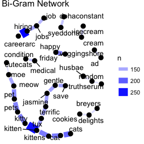

```r
TD_Bigrams <- SAoTD::Bigram(DataFrame = TD_Merge)

SAoTD::Bigram.Network(BiGramDataFrame = TD_Bigrams,
                      number = 100,
                      layout = "fr",
                      edge_color = "blue",
                      node_color = "black",
                      node_size = 3,
                      set_seed = 1234)
```

Additionally we can observe the Correlation Network.

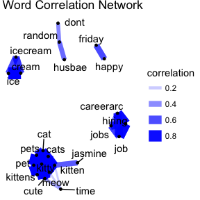

```r
TD_Corr <- SAoTD::Word.Corr(DataFrameTidy = TD_Tidy, number = 200, sort = TRUE)

SAoTD::Word.Corr.Plot(WordCorr = TD_Corr,
                      Correlation = .1,
                      layout = "fr",
                      edge_color = "blue",
                      node_color = "black",
                      node_size = 1)
```